# SimInf Package Explorations

### Two Population Stochastic SEIR metapopulation model with SimInf

Next, we will consider a two subpopulation stochastic SEIR metapopulation model with mparse in SimInf.

```r
siminf_pop2 <- function(N = c(1e6, 1e6), I0 = c(0,1), v = c(0.95, 0.5),
                        beta = 5, sigma = 1/7, gamma = 1/7,
                        coupling = epiNetwork::make_coupling(n = 2, N = c(1e6, 1e6),
                                                             coeffs = matrix(c(0.998, 0.002, 0.1, 0.9),
                                                                             nrow = 2, ncol = 2)),
                        tf = 100, sims = 1) {

  # All state transitions
  transitions <- c("S1 -> beta * (c11 * S1 * I1 / N1 + c12 * S1 * I2 / N2) -> E1",
                   "E1 -> sigma * E1 -> I1",
                   "I1 -> gamma * I1 -> R1",
                   "S2 -> beta * (c21 * S2 * I1 / N1 + c22 * S2 * I2 / N2) -> E2",
                   "E2 -> sigma * E2 -> I2",
                   "I2 -> gamma * I2 -> R2")
  # Compartments
  compartments <- c("S1", "E1", "I1", "R1", "S2", "E2", "I2", "R2")

  # Initial condition vector
  initialization <- function(N, I0, v) {
    vaccinated <- unlist(purrr::map2(v, N, function(x, y) round(x * (y - 1))))
    x0 <- unlist(purrr::pmap(list(I0, vaccinated, N), function(x, y, z) c(z - x - y, 0, x, y)))
    names(x0) <- unlist(purrr::map(seq(1, length(N)), function(x) c(paste0("S", x), paste0("E", x),
                                                                    paste0("I", x), paste0("R", x))))
    data.frame(as.list(x0))
  }
  u0 <- initialization(N = N, I0 = I0, v = v)

  # Global data
  gdata = c(beta = beta, sigma = sigma, gamma = gamma, c11 = coupling[1, 1],
            c21 = coupling[2, 1], c12 = coupling[1, 2], c22 = coupling[2, 2],
            N1 = N[1], N2 = N[2])

  # Construct the model
  model <- mparse(transitions = transitions, compartments = compartments,
                  gdata = gdata, u0 = u0, tspan = 1:tf)

  # Run the simulations and return a list of the trajectories
  simulation <- function(x) {
    result <- run(model = model); return(trajectory(model = result))
  }
  purrr::rerun(sims, simulation())
}
```

Let’s try it with the default parameters.

```r
set.seed(123)
sim3 <- siminf_pop2(sims = 1)
```

which gives,

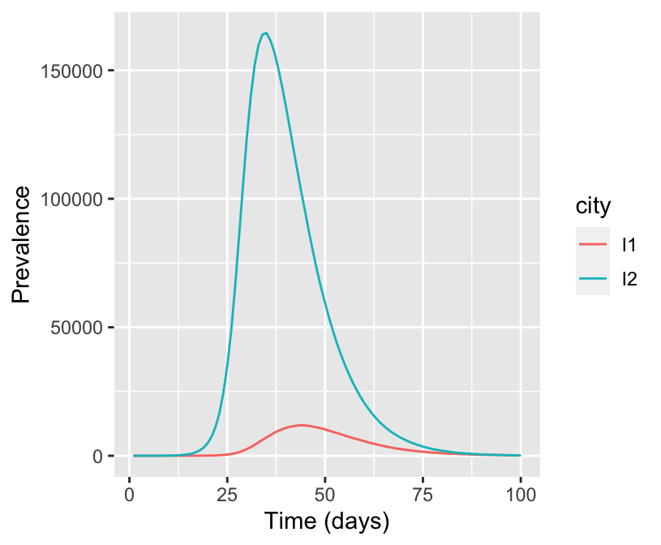

```r
sim3[[1]] %>% dplyr::select(time, I1, I2) %>%
  gather(key = city, value = number, I1, I2) %>%
  ggplot(aes(x = time, y = number, color = city, group = city)) + geom_line() +
  labs(x = "Time (days)", y = "Prevalence")
```

Let’s try the SEIR model implemented with adaptivetau.

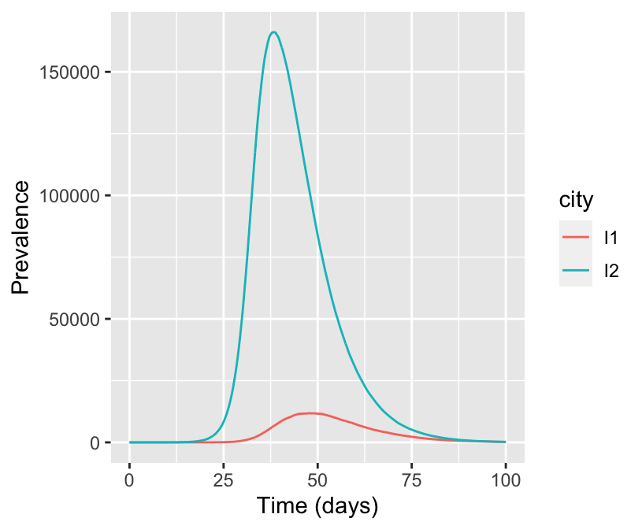

```r
coeffs <- epiNetwork::make_coupling(n = 2, N = c(1e6, 1e6),
                                    coeffs = matrix(c(0.998, 0.002, 0.1, 0.9), nrow = 2, ncol = 2))
sim4 <- epiNetwork::seir_popN(n = 2, N = c(1e6, 1e6), I0 = c(0,1), v = c(0.95, 0.5),
                              beta = 5, sigma = 1/7, gamma = 1/7, coupling = coeffs, tf = 100)

sim4 %>% dplyr::select(time, I1, I2) %>%
  gather(key = city, value = number, I1, I2) %>%
  ggplot(aes(x = time, y = number, color = city, group = city)) + geom_line() +
  labs(x = "Time (days)", y = "Prevalence")
```

Let’s calculate the average time until the peak of the epidemic in population 1 and population 2 in siminf model and the epiNetwork model. This will also serve as an opportunity to compare the running times of each of the models.

```r
# Returns the average time of peak infection in sims simulations of the SimInf SEIR model
f1 <- function(sims) {
  simulations <- siminf_pop2(sims = sims)
  colMeans(do.call(rbind, purrr::map(simulations, function(x) c(x[which.max(x$I1), 2],x[which.max(x$I2), 2]))))
}

# Returns the average time of peak infection in sims simulations of the adaptivetau SEIR model
f2 <- function(sims, n = 2, N = c(1e6, 1e6), I0 = c(0,1), v = c(0.95, 0.5),
               beta = 5, sigma = 1/7, gamma = 1/7, coupling, tf = 100, exact = FALSE) {
  simulations <- purrr::rerun(sims, epiNetwork::seir_popN(n = n, N = N, I0 = I0,
                                                          v = v, beta = beta, sigma = sigma,
                                                          gamma = gamma, coupling = coeffs, tf = tf))
  colMeans(do.call(rbind, purrr::map(simulations, function(x) c(x[which.max(x$I1), 1],x[which.max(x$I2), 1]))))
}
```

```r
library(timeR)
timer <- createTimer(FALSE)
n <- 1000
timer$start("SimInf Model")
SimInfModel <- f1(sims = n)
timer$stop("SimInf Model")
coeffs <- epiNetwork::make_coupling(n = 2, N = c(1e6, 1e6),
                                    coeffs = matrix(c(0.998, 0.002, 0.1, 0.9), nrow = 2, ncol = 2))
timer$start("epiNetwork Model")
epiNetworkModel <- f2(sims = n, coupling = coeffs)
timer$stop("epiNetwork Model")
```

```r
data.frame("SimInf Peak =" =  SimInfModel)
```

```
##   SimInf.Peak..
## 1        43.221
## 2        34.658
```

```r
data.frame("adaptivetau Peak" = epiNetworkModel)
```

```
##   adaptivetau.Peak
## 1         43.67972
## 2         35.04069
```

```r
timer
```

```
## Your Table is:
##              event               start                 end timeElapsed comment
## 1     SimInf Model 2020-06-25 12:37:29 2020-06-25 12:41:12         223    <NA>
## 2 epiNetwork Model 2020-06-25 12:41:12 2020-06-25 12:47:58         406    <NA>
```